# Reproducible Research: Peer Assessment 1

## Loading and preprocessing the data

```r
setwd("~/RepData_PeerAssessment1")
data <- read.csv('activity.csv')
data$date <- as.Date(data$date,'%Y-%m-%d')
```

## What is mean total number of steps taken per day?

**Below is the histogram of the total number of steps taken each day:**

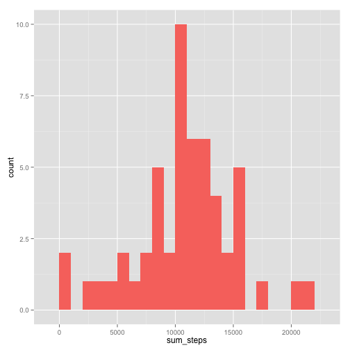

```r
clean_data <- na.omit(data)
sum_step <- aggregate(clean_data$steps, by=list(clean_data$date),sum)
colnames(sum_step) <- c('date','sum_steps')
library(ggplot2)
qplot(sum_steps, data=sum_step,geom='histogram',binwidth=1000,fill='red')+theme(legend.position='none')
```

**Here is the summarized table of mean and median total number of steps taken per day:**

```r
library(plyr)
library(xtable)
mm_steps <- ddply(clean_data,~date,summarise,mean_steps=mean(steps),median_steps=median(steps))
mm_steps$date <- as.character(mm_steps$date)
xt <- xtable(mm_steps)
print(xt,type="html")
```

|  | date | mean_steps | median_steps |
| --- | --- | --- | --- |
| 1 | 2012-10-02 | 0.44 | 0.00 |
| 2 | 2012-10-03 | 39.42 | 0.00 |
| 3 | 2012-10-04 | 42.07 | 0.00 |
| 4 | 2012-10-05 | 46.16 | 0.00 |
| 5 | 2012-10-06 | 53.54 | 0.00 |
| 6 | 2012-10-07 | 38.25 | 0.00 |
| 7 | 2012-10-09 | 44.48 | 0.00 |
| 8 | 2012-10-10 | 34.38 | 0.00 |
| 9 | 2012-10-11 | 35.78 | 0.00 |
| 10 | 2012-10-12 | 60.35 | 0.00 |
| 11 | 2012-10-13 | 43.15 | 0.00 |
| 12 | 2012-10-14 | 52.42 | 0.00 |
| 13 | 2012-10-15 | 35.20 | 0.00 |
| 14 | 2012-10-16 | 52.38 | 0.00 |
| 15 | 2012-10-17 | 46.71 | 0.00 |
| 16 | 2012-10-18 | 34.92 | 0.00 |
| 17 | 2012-10-19 | 41.07 | 0.00 |
| 18 | 2012-10-20 | 36.09 | 0.00 |
| 19 | 2012-10-21 | 30.63 | 0.00 |
| 20 | 2012-10-22 | 46.74 | 0.00 |
| 21 | 2012-10-23 | 30.97 | 0.00 |
| 22 | 2012-10-24 | 29.01 | 0.00 |
| 23 | 2012-10-25 | 8.65 | 0.00 |
| 24 | 2012-10-26 | 23.53 | 0.00 |
| 25 | 2012-10-27 | 35.14 | 0.00 |
| 26 | 2012-10-28 | 39.78 | 0.00 |
| 27 | 2012-10-29 | 17.42 | 0.00 |
| 28 | 2012-10-30 | 34.09 | 0.00 |
| 29 | 2012-10-31 | 53.52 | 0.00 |
| 30 | 2012-11-02 | 36.81 | 0.00 |
| 31 | 2012-11-03 | 36.70 | 0.00 |
| 32 | 2012-11-05 | 36.25 | 0.00 |
| 33 | 2012-11-06 | 28.94 | 0.00 |
| 34 | 2012-11-07 | 44.73 | 0.00 |
| 35 | 2012-11-08 | 11.18 | 0.00 |
| 36 | 2012-11-11 | 43.78 | 0.00 |
| 37 | 2012-11-12 | 37.38 | 0.00 |
| 38 | 2012-11-13 | 25.47 | 0.00 |
| 39 | 2012-11-15 | 0.14 | 0.00 |
| 40 | 2012-11-16 | 18.89 | 0.00 |
| 41 | 2012-11-17 | 49.79 | 0.00 |
| 42 | 2012-11-18 | 52.47 | 0.00 |
| 43 | 2012-11-19 | 30.70 | 0.00 |
| 44 | 2012-11-20 | 15.53 | 0.00 |
| 45 | 2012-11-21 | 44.40 | 0.00 |
| 46 | 2012-11-22 | 70.93 | 0.00 |
| 47 | 2012-11-23 | 73.59 | 0.00 |
| 48 | 2012-11-24 | 50.27 | 0.00 |
| 49 | 2012-11-25 | 41.09 | 0.00 |
| 50 | 2012-11-26 | 38.76 | 0.00 |
| 51 | 2012-11-27 | 47.38 | 0.00 |
| 52 | 2012-11-28 | 35.36 | 0.00 |
| 53 | 2012-11-29 | 24.47 | 0.00 |

## What is the average daily activity pattern?

**Below is a time series plot of the 5-minute interval and the average number of steps taken, averaged across all days:**

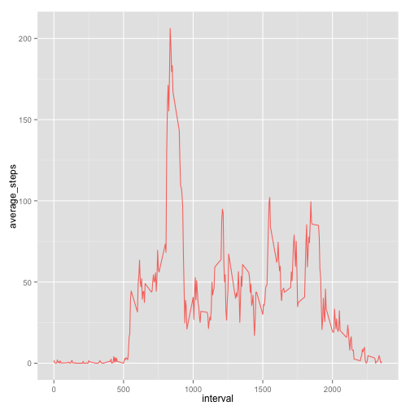

```r
aver_step <- aggregate(clean_data$steps, by=list(clean_data$interval),mean)
colnames(aver_step) <- c('interval','average_steps')
qplot(x=interval,y=average_steps,data=aver_step,geom='line',color ='red')+theme(legend.position='none')
```

**Interval that contains the maximum number of steps:**

```r
aver_step[aver_step$average_steps == max(aver_step$average_steps),1]
```

```
## [1] 835
```

## Imputing missing values

**The total number of missing values in the dataset:**

```r
sum(is.na(data))
```

```
## [1] 2304
```

**Replacing Strategy: replace all of the missing values in the dataset using the mean for that 5-minute interval**

```r
data2 <- data
rep_func <- function(table1,table2){
  for (i in 1:nrow(table1)){
    if (is.na(table1[i,1])){
      j=i-as.integer((i-1)/288)*288
      table1[i,1] <- table2[j,2]
    }
  }
  return(table1)
}
rep_data <- rep_func(data2,aver_step)
```

**Below is the histogram of the total number of steps taken each day based on the new dataset:**

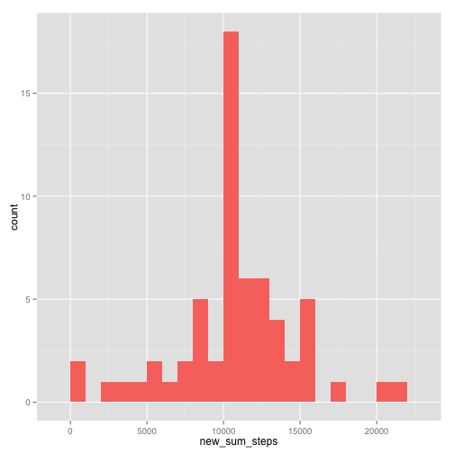

```r
new_sum_step <- aggregate(rep_data$steps, by=list(rep_data$date),sum)
colnames(new_sum_step) <- c('date','new_sum_steps')
library(ggplot2)
qplot(new_sum_steps, data=new_sum_step,geom='histogram',binwidth=1000,fill='red')+theme(legend.position='none')
```

**Here is the summarized table of mean and median total number of steps taken per day based on the new dataset:**

```r
new_mm_steps <- ddply(rep_data,~date,summarise,mean_steps=mean(steps),median_steps=median(steps))
new_mm_steps$date <- as.character(new_mm_steps$date)
rep_xt <- xtable(new_mm_steps)
print(rep_xt,type="html")
```

|  | date | mean_steps | median_steps |
| --- | --- | --- | --- |
| 1 | 2012-10-01 | 37.38 | 34.11 |
| 2 | 2012-10-02 | 0.44 | 0.00 |
| 3 | 2012-10-03 | 39.42 | 0.00 |
| 4 | 2012-10-04 | 42.07 | 0.00 |
| 5 | 2012-10-05 | 46.16 | 0.00 |
| 6 | 2012-10-06 | 53.54 | 0.00 |
| 7 | 2012-10-07 | 38.25 | 0.00 |
| 8 | 2012-10-08 | 37.38 | 34.11 |
| 9 | 2012-10-09 | 44.48 | 0.00 |
| 10 | 2012-10-10 | 34.38 | 0.00 |
| 11 | 2012-10-11 | 35.78 | 0.00 |
| 12 | 2012-10-12 | 60.35 | 0.00 |
| 13 | 2012-10-13 | 43.15 | 0.00 |
| 14 | 2012-10-14 | 52.42 | 0.00 |
| 15 | 2012-10-15 | 35.20 | 0.00 |
| 16 | 2012-10-16 | 52.38 | 0.00 |
| 17 | 2012-10-17 | 46.71 | 0.00 |
| 18 | 2012-10-18 | 34.92 | 0.00 |
| 19 | 2012-10-19 | 41.07 | 0.00 |
| 20 | 2012-10-20 | 36.09 | 0.00 |
| 21 | 2012-10-21 | 30.63 | 0.00 |
| 22 | 2012-10-22 | 46.74 | 0.00 |
| 23 | 2012-10-23 | 30.97 | 0.00 |
| 24 | 2012-10-24 | 29.01 | 0.00 |
| 25 | 2012-10-25 | 8.65 | 0.00 |
| 26 | 2012-10-26 | 23.53 | 0.00 |
| 27 | 2012-10-27 | 35.14 | 0.00 |
| 28 | 2012-10-28 | 39.78 | 0.00 |
| 29 | 2012-10-29 | 17.42 | 0.00 |
| 30 | 2012-10-30 | 34.09 | 0.00 |
| 31 | 2012-10-31 | 53.52 | 0.00 |
| 32 | 2012-11-01 | 37.38 | 34.11 |
| 33 | 2012-11-02 | 36.81 | 0.00 |
| 34 | 2012-11-03 | 36.70 | 0.00 |
| 35 | 2012-11-04 | 37.38 | 34.11 |
| 36 | 2012-11-05 | 36.25 | 0.00 |
| 37 | 2012-11-06 | 28.94 | 0.00 |
| 38 | 2012-11-07 | 44.73 | 0.00 |
| 39 | 2012-11-08 | 11.18 | 0.00 |
| 40 | 2012-11-09 | 37.38 | 34.11 |
| 41 | 2012-11-10 | 37.38 | 34.11 |
| 42 | 2012-11-11 | 43.78 | 0.00 |
| 43 | 2012-11-12 | 37.38 | 0.00 |
| 44 | 2012-11-13 | 25.47 | 0.00 |
| 45 | 2012-11-14 | 37.38 | 34.11 |
| 46 | 2012-11-15 | 0.14 | 0.00 |
| 47 | 2012-11-16 | 18.89 | 0.00 |
| 48 | 2012-11-17 | 49.79 | 0.00 |
| 49 | 2012-11-18 | 52.47 | 0.00 |
| 50 | 2012-11-19 | 30.70 | 0.00 |
| 51 | 2012-11-20 | 15.53 | 0.00 |
| 52 | 2012-11-21 | 44.40 | 0.00 |
| 53 | 2012-11-22 | 70.93 | 0.00 |
| 54 | 2012-11-23 | 73.59 | 0.00 |
| 55 | 2012-11-24 | 50.27 | 0.00 |
| 56 | 2012-11-25 | 41.09 | 0.00 |
| 57 | 2012-11-26 | 38.76 | 0.00 |
| 58 | 2012-11-27 | 47.38 | 0.00 |
| 59 | 2012-11-28 | 35.36 | 0.00 |
| 60 | 2012-11-29 | 24.47 | 0.00 |
| 61 | 2012-11-30 | 37.38 | 34.11 |

### What is the impact of imputing missing data on the estimates of the total daily number of steps?

**For the mean data, all the missing days that were removed previously came back in the list. I didn't see much influence on the existing mean values.

For the median data, instead of being 0 in all of the days, some values changed to 34.11.**

## Are there differences in activity patterns between weekdays and weekends?

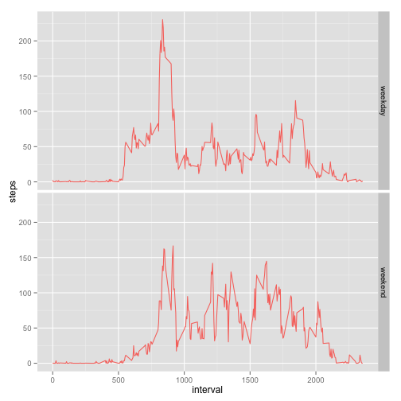

```r
rep_data$weekday <- weekdays(rep_data$date)
rep_data$weektime <- as.factor(ifelse(rep_data$weekday%in% c("Saturday","Sunday"),"weekend", "weekday"))
new_aver_step <- aggregate(steps~interval+weektime, data=rep_data,mean)
qplot(interval,steps,data=new_aver_step,geom='line',color='red',facets=weektime~.)+theme(legend.position='none')
```

**From the plot we can see that the activities distribute more evenly on weekends, with similar amount of activities through out the day. I think the experimenter likes to go out in the weekends, like hiking. So the activities are quite consistent. While on weekdays, more activities are taken place in the morning, as the highest point in the plot shows. I guess this experimenter perhaps does some exercise in the morning and then go to work. Because the office work is mostly about staying in his own cube and work with computer. so his activities drops down from the late morning to the rest of the day.**